# Laplacian Smoothing tools for Modo plug-in

This is a Modo Plug-in kit to smooth mesh vertex positions using Laplacian algorithm based on a curvature flow Laplace Beltrami operator in a diffusion equation. This allows you to reduce noise on a mesh’s surface with minimal changes to its shape.

This kit contains a direct modeling tool and a procedural mesh operator for Modo macOS and Windows.

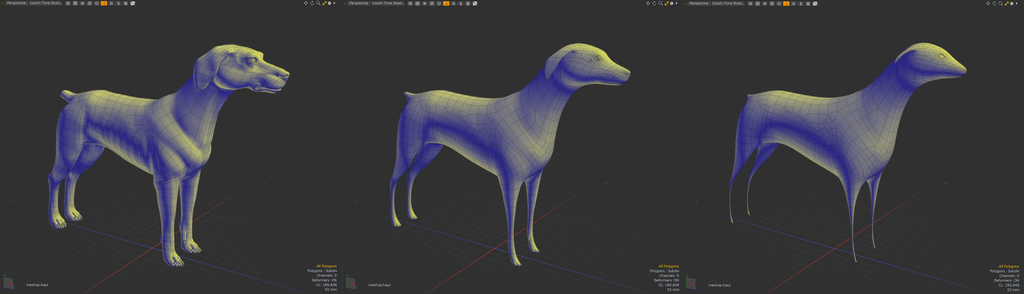

strength: 0.0, 1.0, 2.0 from left to right

## Installing

- Download lpk from releases. Drag and drop into your Modo viewport. If you’re upgrading, delete previous version.

## How to use Laplacian tool

The laplacian smoothing tool is named **xfrm.laplacian**. Type **tool.set xfrm.laplacian on** on command field of command history viewport. After setup the laplacian smoothing tool, you can see **Strength** attribute on the tool property viewport. This supports falloff weights.

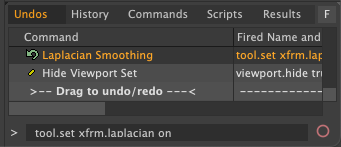

The procedural mesh operator as **Laplacian Smoothing** is under Deform tab on Mesh Operator viewport.

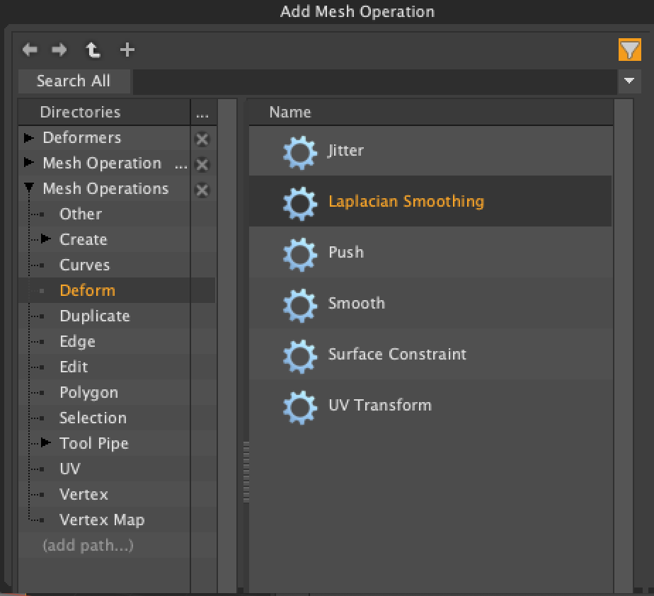

## Dependencies

- LXSDK  
  This kit requires Modo SDK (Modo 16.1v8 or later). Download LXSDK and set you LXSDK path to LXSDK_PATH in CMakeLists.txt in triagulate.
- libigl 2.5.0 (https://github.com/libigl/libigl)  
  This also requires Igl library. Download libigl and set the include path to LIBIGL_PATH in CMakeLists.txt. libigl is header only library.
- Eigen 3.4.0 (https://gitlab.com/libeigen/eigen)  
  This also requires Eigen library. Download eigen and set the include path to EIGEN_PATH in CMakeLists.. Eigen is header only library

## License

```
This software is based part on libigl : A simple c++ geometry processing library:
Copyright 2013 - Alec Jacobson, Daniele Panozzo, Olga Diamanti, Kenshi
Takayama, Leo Sacht, Interactive Geometry Lab - ETH Zurich
https://libigl.github.io
Licensed under the MPL-2.0 license.
```